# Inferencia Estadística I, 2019

## 23 de agosto de 2019

## Sobre la Guía 1

Para tus tres distribuciones, que serán tus hijas adoptivas este semestre, busca la expresión de la función de densidad o de probabilidad \(f(x;\theta)\) y de la distribución correspondiente \(F(x;\theta)\) en el caso que tenga expresión analítica cerrada.

Responde para cada una de ellas lo siguiente:

1. Indica de qué tipo es cada parámetro de la distribución.
2. Describe el tipo de fenómenos aleatorios que suele describir tu distribución. Da algunos ejemplos.

## Weibull de mínimos de dos parámetros

La densidad de la distribución Weibull de mínimos (de 2 parámetros) está dada por la expresión:

\[f(t;\eta,\beta)=\frac{\beta}{\eta}\left(\frac{t}{\eta}\right)^{\beta-1}e^{-(t/\eta)^\beta}1\!\!1\,\,_{(0<t<\infty)}\]

Y su función de distribución está dada por:

\[F(t;\eta,\beta)=\left[1-e^{-(t/\eta)^\beta}\right]1\!\!1\,\,_{(0<t<\infty)}\]

donde \(\beta > 0\) es el parámetro de forma y \(\eta > 0\) es el parámetro de escala.

Según Bloch y Geitner (1994) la distribución Weibull se suele utilizar para describir la vida de componentes electrónicas, cerámicas, capacitores y dieléctricos en pruebas aceleradas.

3. Demuestra si tu distribución pertenece o no a la familia exponencial de distribuciones con \(k\) parámetros, donde \(k=\text{dim}(\theta)\).

Note que la función de densidad puede ser escrita como:

\[f(t;\eta,\beta)=\frac{\beta}{\eta^\beta}1\!\!1\,\,_{(0<t<\infty)}\exp\left\{(\beta-1)\log t-(t/\eta)^\beta\right\}\]

La expresión \((t/\eta)^\beta\) **NO** puede ser escrita de la forma \(C(\theta)D(t)\). Esto sucede, en general con parámetros que aparecen como exponentes de exponentes.

Por lo que la distribución Weibull de mínimos (de dos parámetros) **NO** pertenece a la familia exponencial.

**La factorización no es necesariamente única.**

4. Demuestra si la distribución pertenece o no a la familia de distribuciones de localización y escala.

Sea \(T\sim\text{Weibull}_{min}(\eta,\beta)\) y sea \(Y=\frac{T-\beta}{\eta}\). Entonces, por el Teorema de Cambio de Variable, la función de distribución de \(Y\) está dada por:

\[\begin{align*} F_Y(y;\eta,\beta)&=F_T(\eta y+\beta;\eta,\beta)\\ &=\left[1-\exp\left\{-[(\eta y+\beta)/\eta]^\beta\right\}\right]1\!\!1\,\,_{(0<\eta y+\beta<\infty)}\\ &=\left[1-\exp\left\{-[y+\beta/\eta]^\beta\right\}\right]1\!\!1\,\,_{(-\eta/\beta < y <\infty)} \end{align*}\]

Que depende de parámetros desconocidos.

Por lo tanto, la distribución Weibull de mínimos (de dos parámetros) **NO** pertenece a la familia de localización y escala.

Pero pertenece a la familia de log-localización y escala **¿Por qué?**

5. Indica alguna relación que guarde tu ‘hija adoptiva’ con alguna otra dustribución (revisa Evans, Hastings & Peackock y el vol. 1 de Kalbfleisch, 1985) o si alguna transformación de ella la liga con alguna otra distribución.

Cuando el parámetro de forma \(\beta=1\), se tiene una distribución exponencial de media \(\eta\).

Cuando el parámetro de forma \(\beta=2\), se tiene una distribución Rayleigh.

Si \(T\sim\text{Weibull}_{\text{min}}\), entonces \(\log(T)\) sigue una distribución Gumbel de mínimos **¿Con qué parámetros?**, que pertenece a la familia de localización y escala. Por eso la distribución Weibull es de log-localización y escala.

6. Grafica \(f(x;\theta)\) para varios valores de \(\theta\). ¿Existe alguna combinación de los parámetros que logre que \(f\) sea simétrica alrededor de la moda?

```r
# Definimos la función de densidad
dweib_min <- function(x, eta=1, beta=1){
  beta/eta*(x/eta)^(beta-1)*exp(-(x/eta)^beta)
}
```

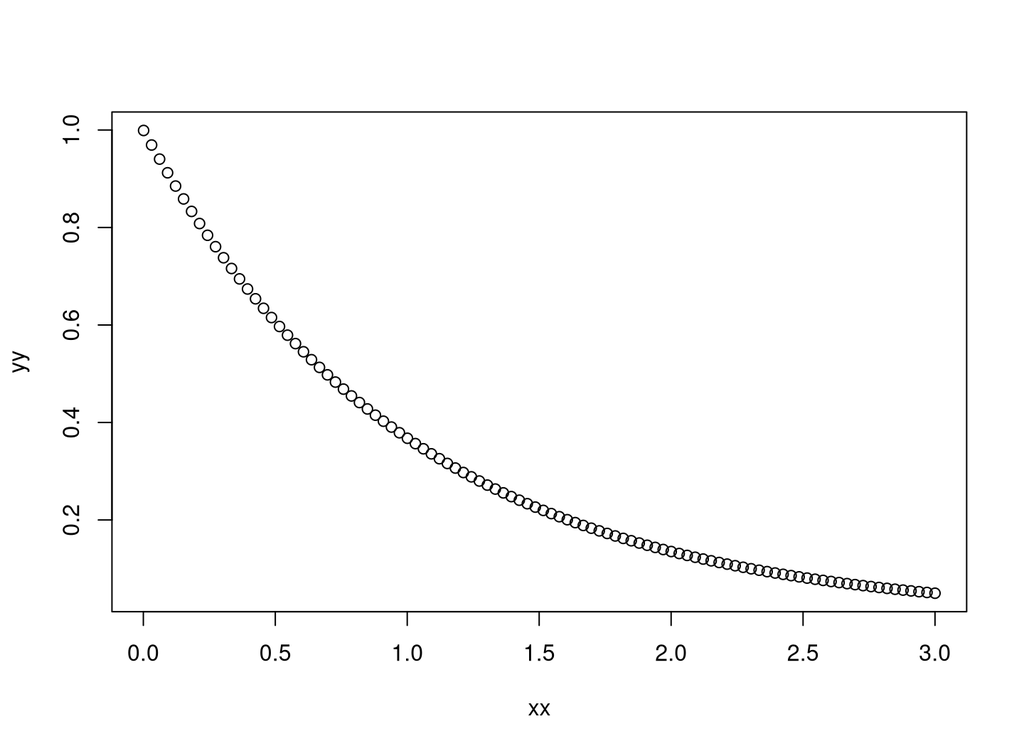

```r
# Hacemos una secuancia de valores para x
xx <- seq(0.001,3,length=100)

# Evaluamos la función en xx
yy <- rep(0,100)

for (i in 1:100){
  yy[i] <- dweib_min(xx[i])
}

plot(xx,yy)
```

## Exportando gráficos

```r
# Hacemos una secuancia de valores para x
xx <- seq(0.001,3,length=100)

# Evaluamos la función en xx
yy <- rep(0,100)

for (i in 1:100){
  yy[i] <- dweib_min(xx[i])
}

png("ejemplo.png", width=4, height=4, units="in", res=300)
plot(xx,yy)
dev.off()
```

**¡Revisar RStudio!**

Si cambiamos el parámetro \(\eta\)

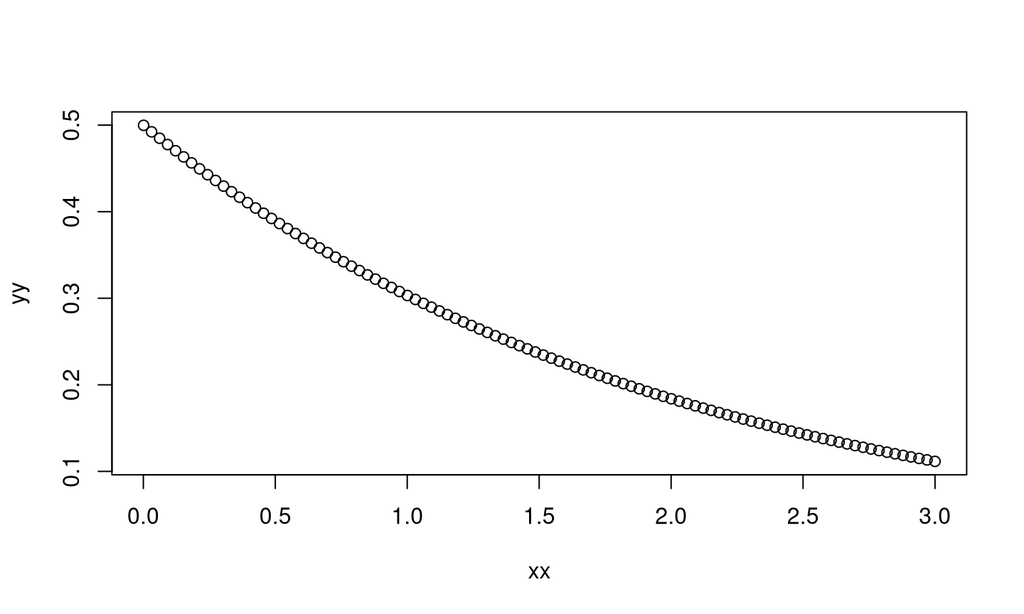

```r
for (i in 1:100){
  yy[i] <- dweib_min(xx[i], eta=2)
}
plot(xx,yy)
```

Si cambiamos el parámetro \(\beta\)

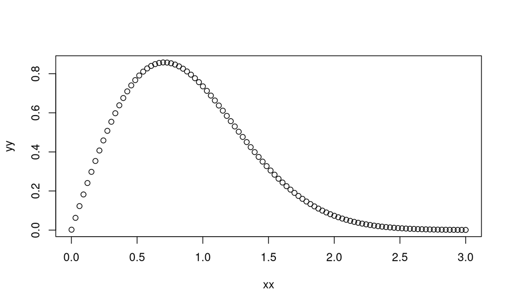

```r
for (i in 1:100){
  yy[i] <- dweib_min(xx[i], beta=2)
}
plot(xx,yy)
```

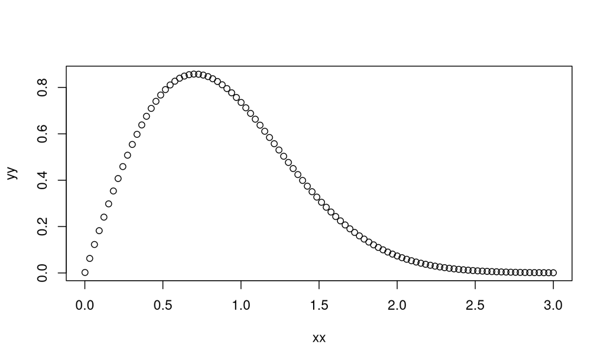

```r
yy <- dweib_min(xx,eta=1,beta=2)
plot(xx,yy)
```

Con varios valores de \(\beta\)

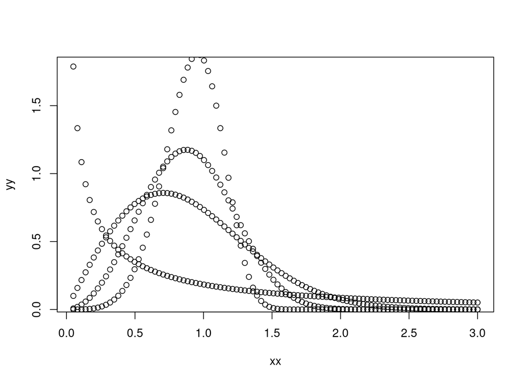

```r
yy <- dweib_min(xx,eta=1,beta=0.5)

plot(xx,yy)

yy2 <- dweib_min(xx,eta=1,beta=2)
yy3 <- dweib_min(xx,eta=1,beta=3)
yy4 <- dweib_min(xx,eta=1,beta=5)

points(xx,yy2)
points(xx,yy3)
points(xx,yy4)
```

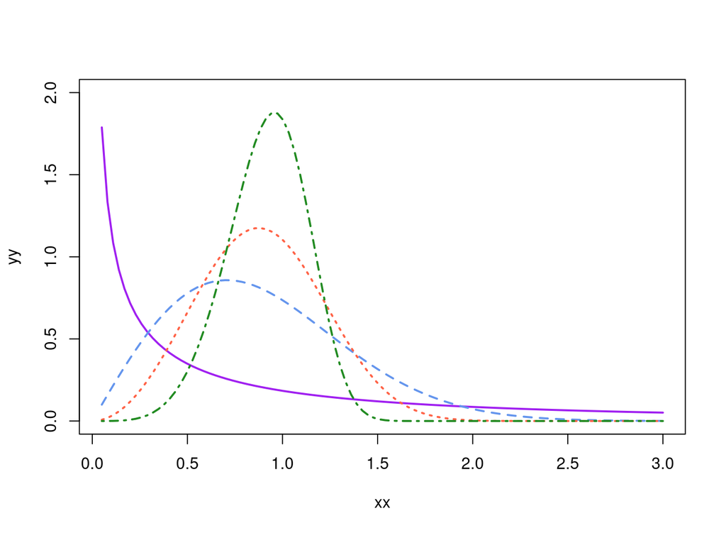

```r
yy <- dweib_min(xx,eta=1,beta=0.5)

plot(xx, yy,
     type='l',      # Tipo 'linea'
     ylim=c(0,2),
     col='purple',
     lty=1,         # Tipo de linea
     lwd=2          # Grosor de linea
     )

(yy2 <- function(x){dweib_min(x,eta=1,beta=2)}) %>%
  curve(add=TRUE, type='l', col='cornflowerblue', lty=2, lwd=2)

#yy2 <- function(x){dweib_min(x,eta=1,beta=2)}
#curve(yy2(x), add=TRUE, type='l', col='cornflowerblue', lty=2, lwd=2)

yy3 <- dweib_min(xx,eta=1,beta=3)
yy4 <- dweib_min(xx,eta=1,beta=5)

points(xx, yy3, type='l', col='tomato', lty=3, lwd=2)
points(xx, yy4, type='l', col='forestgreen', lty=4, lwd=2)
```

[figure not shown]

```r
xx <- seq(0.05,3,length=100)
yy <- dweib_min(xx,eta=1,beta=0.5)

# Modificamos los margenes
par(mar=c(5,5,2,2))

plot(xx, yy,
     type='l',      # Tipo 'linea'
     ylim=c(0,2),
     col='purple',
     lty=1,         # Tipo de linea
     lwd=2,         # Grosor de linea
     xlab='x',
     ylab=expression(f(x,theta)),
     main='Densidad Weibull de minimos (de dos parametros)',
     cex.lab=1.5)

(yy2 <- function(x){dweib_min(x,eta=1,beta=2)}) %>%
  curve(add=TRUE, type='l', col='cornflowerblue', lty=2, lwd=2)

yy3 <- dweib_min(xx,eta=1,beta=3)
yy4 <- dweib_min(xx,eta=1,beta=5)

points(xx, yy3, type='l', col='tomato', lty=3, lwd=2)
points(xx, yy4, type='l', col='forestgreen', lty=4, lwd=2)

# Las leyendas del gráfico
nom <- c(expression(paste(eta, '=1, ', beta, '=2')),
         expression(paste(eta, '=1, ', beta, '=3')),
         expression(paste(eta, '=1, ', beta, '=5')))

colores <- c('purple', 'cornflowerblue', 'tomato', 'forestgreen')

legend('topright', legend=nom, lwd=2, lty=c(1,2,3,4),
       col=colores, bty='n', cex=1.5)
```

## Coeficiente de simetría de Pearson

Sea \(X\) una v.a. con tercer momento, el coeficiente de simetría de Pearson se define como:

\[\mathbb{E}\left[\left(\frac{X-\mu}{\sigma}\right)^3\right]\]

Se puede demostrar que es equivalente a:

\[\frac{\mathbb{E}[X^3]-3\mu\sigma^2-\mu^3}{\sigma^3}\]

Si el coeficiente es igual a cero, \(X\) es simétrica.

En el caso de la distribución Weibull este coeficiente está dado por:

\[\begin{align*} \mu&=\eta\Gamma(1+1/\beta)\\ \sigma^2&=\eta^2\left[\Gamma\left(1+\frac{2}{\beta}\right) - \left(\Gamma\left(1+\frac{1}{\beta}\right)\right)^2\right]\\ \mathbb{E}[X^3]&=\eta^3\Gamma(1+3/\beta) \end{align*}\]

Por lo que el coeficiente de simetría es:

\[\frac{\Gamma(1+3/\beta)-3\Gamma(1+1/\beta)\left[\Gamma\left(1+\frac{2}{\beta}\right) - \left(\Gamma\left(1+\frac{1}{\beta}\right)\right)^2\right]-\left[\Gamma(1+1/\beta)\right]^3}{\left[\Gamma\left(1+\frac{2}{\beta}\right) - \left(\Gamma\left(1+\frac{1}{\beta}\right)\right)^2\right]^{3/2}}\]

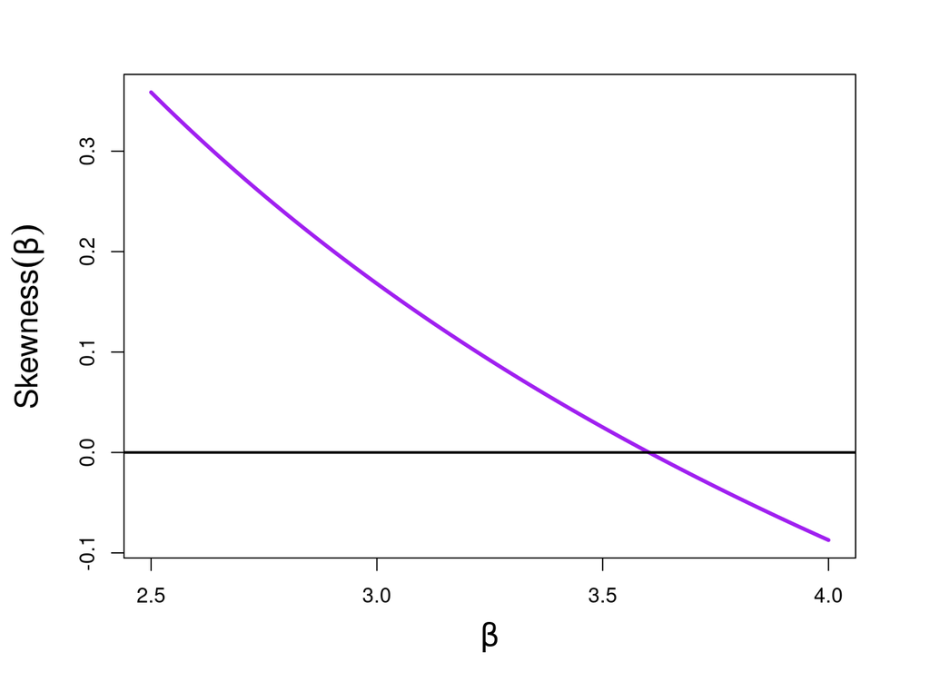

```r
m <- function(x){gamma(1+1/x)}
s <- function(x){sqrt(gamma(1+2/x)-(gamma(1+1/x))^2)}

skew <- function(x){(gamma(1+3/x)-3*m(x)*s(x)^2-m(x)^3)/(s(x)^3)}
xx <- c(2.5,4)
yy <- skew(xx)

par(mar=c(5,5,3,3))

plot(xx,yy,type='n', xlab=expression(beta), ylab = expression(Skewness(beta)), cex.lab=1.5)

curve(skew(x), from=2.5, to=4, lwd=3, col='purple', add=TRUE)

abline(h=0, lwd=2)
```

## Detalle sobre fam. de localización y escala

Considere \(X\sim\text{Unif}_{\text{cont}}(a,b)\), la función de distribución de \(X\) está dada por:

\[F(x;a,b)=\frac{x-a}{b-a}1\!\!1\,\,_{(a<x<b)}+1\!\!1\,\,_{(b\leq x)}\]

Sea \(\mu=a\), \(\sigma=b-a\) y \(Y=\frac{X-\mu}{\sigma}\), su función de distribución está dada por:

\[\begin{align*} F_Y(y;\mu,\sigma)&=F_X((b-a)y+a;a,b)\\ &=\frac{(b-a)y+a-a}{b-a}1\!\!1\,\,_{}(a<(b-a)y+a<b)+1\!\!\,\,_{(b\leq (b-a)y+a)}\\ &=y1\!\!\,\,_{(0<y<1)}+1\!\!\,\,_{(1\leq y)} \end{align*}\]

que no depende de parámetros desconocidos, incluso cuando el soporte de \(X\) SÍ depende de parámetros desconocidos.

Por lo tanto, la distribución \(\text{Unif}_{\text{cont}}(a,b)\) SÍ pertenece a la familia de lozaclización y escala con parámetros de localización \(\mu=a\) y escala \(\sigma=b-a\).

De manera análoga, se puede mostrar que la distribución Uniforme Discreta también pertenece a esta familia.

## Simulación de variables aleatorias

## Función de cuantiles

Sea \(0\leq \alpha\leq 1\) y sea \(X\) una v.a. con función de distribución \(F(x;\theta)\), la función de cuantiles está dada por:

\[Q(\alpha)=F^{-}(\alpha;\theta)=\inf\{x:\,F(x;\theta)\geq x\}\]

Recuerde que, en el caso de la distribución Weibull de dos parámetros, la función de distribución está dada por:

\[F(t;\eta,\beta)=\left[1-e^{-(t/\eta)^\beta}\right]1\!\!1\,\,_{(0<t<\infty)}\]

Por lo que, su función de cuantiles está dada por:

\[Q(\alpha)=\eta\left[\log\left(\frac{1}{1-\alpha}\right)\right]^{1/\beta}1\!\!1\,\,_{(0<\alpha<1)}\]

## Teorema Integral de Probabilidad

Si \(U\sim\text{Unif}_\text{cont}[0,1]\), entonces la v.a. \(F^{⁻}_X(U)\) tiene la misma distribución que \(X\).

**Simular una muestra Weibull**

```r
# Funcion cuantiles
qweib_min <- function(x,eta=1,beta=1){eta*((1/(1-x)) %>% log)^(1/beta)}

# Función que genera una muestra (simple) de la distribucion Weibull
rweib_min <- function(n,eta=1,beta=1){
  u <- runif(n) #Generamos una muestra uniforme
  out <- qweib_min(u,eta,beta)
  return(out)
}
```

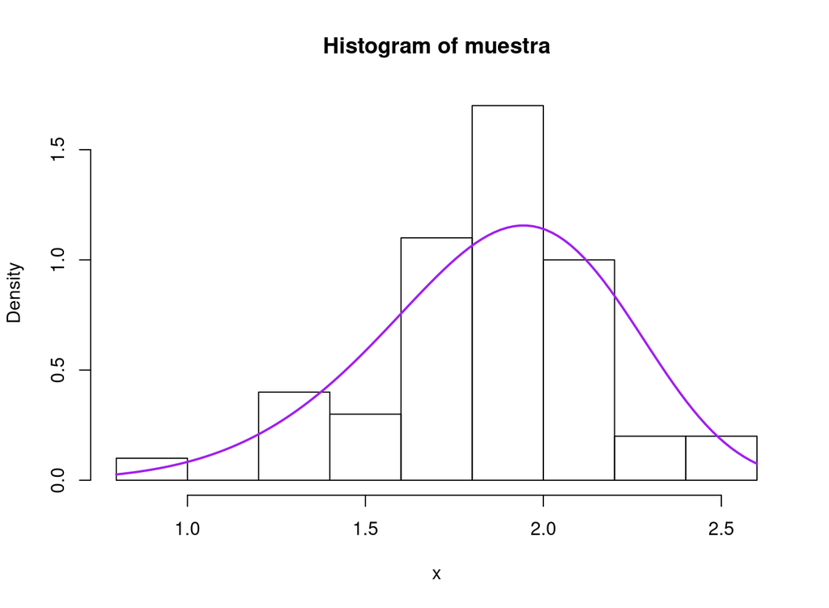

```r
# Ejemplo
set.seed(111)
nn <- 50
ee <- 2
bb <- 6.2
muestra <- rweib_min(nn, eta=ee, beta=bb)

# Hacemos un histograma con nuestra muestra
hist(muestra, freq = FALSE, xlab='x')

# Le encimamos la densidad Weibull
(aux <- function(x){dweib_min(x,eta=ee,beta=bb)}) %>%
  curve(lwd=2,col='purple', add=TRUE)
```

## Función de distribución empírica

Sea \((x_1,\ldots,x_n)\) una muestra (de cualquier variable aleatoria), la función de distribución empírica se define como:

\[F_n(x)=\frac{1}{n}\sum_{i=1}^n1\!\!1\,\,_{(-\infty,x]}(x_i)\]

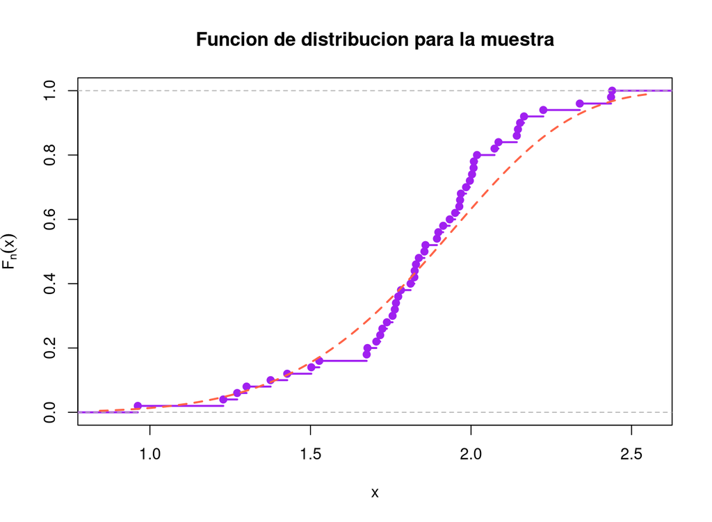

```r
# Funcion de distribucion empirica de nuestra muestra
F.emp<-ecdf(muestra)

tit<-paste("Funcion de distribucion para la muestra") # Titulo del gráfico
plot(F.emp,
     xlab="x", ylab=expression(F[n](x)),
     main=tit, col="purple", lwd=2)

# Funcion de distribucion Weibull
pweib_min <- function(x,eta=1,beta=1){1-exp(-(x/eta)^beta)}

# encimamos la funcion de distribucion
(aux <- function(x){pweib_min(x,eta=ee,beta=bb)}) %>%
  curve(col='tomato', lwd=2, lty=2, add=TRUE)
```

1. Para la distribución Gumbel de máximos, encuentra su función de cuantiles y calcula los cuantiles de probabilidad 0.3679 y 0.5 (la mediana).
2. Usando el Teorema Integral de Probabilidad simula tres muestras simples de una v.a. Gumbel de máximos con parámetro de localización 2 y escala unitaria, los tamaños de las muestras son: \(n=10,\,30,\,100\,\).
3. Con las muestras simuladas en el inciso anterior:
- Grafica su función de distribución empírica y encima la función de distribución teórica.
- Grafica su histograma y encima la función de densidad teórica.
1. Escribe un breve reporte ( 2 páginas máximo ) con tus observaciones y las gráficas, este reporte debes entregarlo en la siguiente ayudantía .